# WGCNA: an R package for weighted correlation network analysis | BMC Bioinformatics | Full Text

### Category 2: Functions for module detection

Once the network has been constructed, module detection is often a logical next step. Modules are defined as clusters of densely interconnected genes. Several measures of network interconnectedness are described in [25]. As default, we we use the topological overlap measure [5, 25–27] since it has worked well in several applications. WGCNA identifies gene modules using unsupervised clustering, i.e. without the use of a priori defined gene sets. The user has a choice of several module detection methods. The default method is hierarchical clustering using the standard R function hclust [28]; branches of the hierarchical clustering dendrogram correspond to modules and can be identified using one of a number of available branch cutting methods, for example the constant-height cut or two Dynamic Branch Cut methods [29].

In Figure 2C we show a network heatmap plot (interconnectivity plot) of a gene network together with the corresponding hierarchical clustering dendrograms and the resulting modules. Figure 2B provides an alternate visualization of the module structure via a multi-dimensional scaling plot (standard R function cmdscale).

One drawback of hierarchical clustering is that it can be difficult to determine how many (if any) clusters are present in the data set. Although the height and shape parameters of the Dynamic Tree Cut method provide improved exibility for branch cutting and module detection, it remains an open research question how to choose optimal cutting parameters or how to estimate the number of clusters in the data set [30]. While our default parameter values have worked well in several applications, in practice we recommend to carry out a cluster stability/robustness analysis. A co-expression module may reflect a true biological signal (e.g. a pathway) or it may reflect noise (e.g. a technical artifacts, tissue contamination, or a false positive). To test whether the identified modules are biologically meaningful, gene ontology information (functional enrichment analysis) can be used. Toward this end, we provide an R tutorial that describes how to interface the WGCNA package with relevant external software packages and databases.

#### Summarizing the profiles of a module

Several options have been implemented for summarizing the gene expression profiles of a given module. For example, the function moduleEigengenes represents the module expressions of the *q*-th module by the module eigengene *E*<sup>(*q*)</sup>, defined as the first principal component of the expression matrix. The eigengene *E* can be thought of as a weighted average expression profile. Eigengene calculation incorporates imputation of missing values implemented in the package impute [31, 32]. Alternatively, the user can use the intramodular connectivity measure to define the most highly connected intramodular hub gene as the module representative. One can show that intramodular hub genes are highly correlated with the module eigengene [11].

#### Fuzzy measure of module membership

Hierarchical clustering and most other standard clustering methods such as Partitioning Around Medoids (PAM) [28] result in a binary module assignment, i.e. a node is either in or outside of a module. In some applications it may be advantageous to define a continuous, fuzzy measure of module membership for all nodes. Such measure is particularly useful to identify nodes that lie near the boundary of a module, or nodes that are intermediate between two or more modules. As explained in detail in [11], the module membership of node *i* in module *q* can be defined as

(6)

where *x*<sub>*i*</sub>is the profile of node *i* and *E*<sup>(*q*)</sup>is the module eigengene of module *q*. The module membership measure lies in [-1, 1] and specifies how close node *i* is to module *q*, *q* = 1, . . ., *Q*. The larger ||, the more similar node *i* is to the eigengene of the *q*-th module. In some publications [14, 15], is referred to as signed module eigengene (ME) based connectivity measure *K*<sub>*ME*</sub>. This is the reason why we named the corresponding R function signedKME.

#### Automatic block-wise module detection

Many microarray gene expression measurements report expression levels of tens of thousands of distinct genes (or probes). Building and analyzing a full network among such a large number of nodes can be computationally challenging because of memory size and processor speed limitations. The WGCNA package contains several improvements that address this challenge. The function blockwiseModules is designed to handle network construction and module detection in large data sets. The function first pre-clusters nodes into large clusters, referred to as blocks, using a variant of k-means clustering (function projectiveKMeans). Next, hierarchical clustering is applied to each block and modules are defined as branches of the resulting dendrogram. To synthesize the module detection results across blocks, an automatic module merging step (function mergeCloseModules) is performed that merges modules whose eigengenes are highly correlated. The time and memory savings of the block-wise approach are substantial: a standard, single-block network analysis of *n* nodes requires *O*(*n*<sup>2</sup>) memory and *O*(*n*<sup>3</sup>) calculations, while the block-wise approach with block size *n*<sub>*b*</sub>requires only *O*() memory and *O*(*n*) calculations, making an analysis of say 50 000 genes in blocks of 7 000 feasible on a standard computer.

#### Consensus module detection

When dealing with multiple adjacency matrices representing different networks, it can be interesting to find *consensus modules*, defined as modules that are present in all or most networks [12]. Intuitively, two nodes should be connected in a consensus network only if all of the input networks agree on that connection. This naturally suggest to define the consensus network similarity between two nodes as the minimum of the input network similarities. In certain cases it may be useful to replace minimum by a suitable quantile (e.g. the first quartile) since the resulting measure may be more robust. Consensus module detection can be performed step-by-step for maximum control and exibility, or in one step using the function blockwiseConsensusModule that calculates consensus modules across given data sets in a block-wise manner analogous to the block-wise module detection in a single data set.

### Category 3: Functions for module and gene selection

Finding biologically or clinically significant modules and genes is a major goal of many co-expression analyses. The definition of biological or clinical significance depends on the research question under consideration. Abstractly speaking, we define a gene significance measure as a function *GS* that assigns a non-negative number to each gene; the higher *GS*<sub>*i*</sub>the more *biologically* significant is gene *i*. In functional enrichment analysis, a gene significance measure could indicate pathway membership. In gene knock-out experiments, gene significance could indicate knock-out essentiality. A microarray sample trait *T* can be used to define a trait-based gene significance measure as the absolute correlation between the trait and the expression profiles, Equation 2. A measure of module significance can be defined as average gene significance across the module genes (Figure 3A). When dealing with a sample trait *T*, a measure of statistical significance between the module eigengene *E* and the trait *T* can be defined, for example, using correlation (Equation 2) or a p-value (Equation 3) obtained from a univariate regression model between *E* and *T*. Modules with high trait significance may represent pathways associated with the sample trait. Genes with high module membership in modules related to traits (Figure 3B) are natural candidates for further validation [10, 14, 15, 18].

**Figure 3**

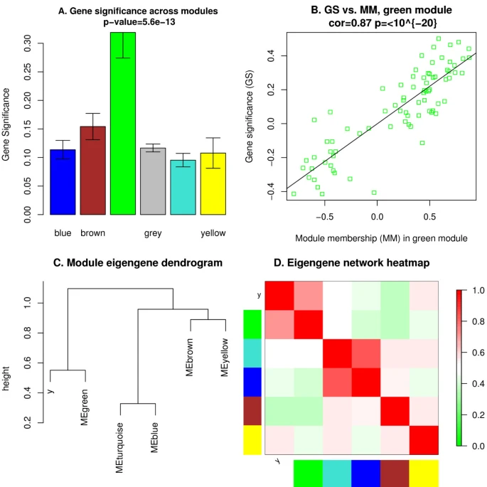

**Module and eigengene network plots**. A. Barplot of mean gene significance across modules. In this example we use a trait-based gene significance, Equation 2. The higher the mean gene significance in a module, the more significantly related the module is to the clinical trait of interest. B. Scatterplot of gene significance (*y*-axis) vs. module membership (*x*-axis) in the most significant module (green module, see panel A). In modules related to a trait of interest, genes with high module membership often also have high gene significance. C. Hierarchical clustering dendrogram of module eigengenes (labeled by their colors) and the microarray sample trait *y*. D. Heatmap plot of the adjacencies in the eigengene network including the trait *y*. Each row and column in the heatmap corresponds to one module eigengene (labeled by color) or the trait (labeled by *y*). In the heatmap, green color represents low adjacency (negative correlation), while red represents high adjacency (positive correlation).

[Full size image](https://bmcbioinformatics.biomedcentral.com/articles/10.1186/1471-2105-9-559/figures/3)

### Category 4: Functions for studying topological properties

Many topological properties of networks can be succinctly described using network concepts, also known as network statistics or indices [11, 33]. Network concepts include whole network connectivity (degree), intramodular connectivity, topological overlap, the clustering coefficient, density etc. Differential analysis of network concepts such as intramodular connectivity may reveal regulatory changes in gene expressions [15, 18]. The WGCNA package implements several functions, such as softConnectivity, intramodularConnectivity, TOMSimilarity, clusterCoef, networkConcepts, for computing these network concepts. Basic R functions can be used to create summary statistics of these concepts and for testing their differences across networks.

#### Network concepts for measuring cluster structure

Gene clustering trees and TOM plots that visualize interconnectivity patterns often suggest the presence of large modules. Network theory offers a wealth of intuitive network concepts for describing the pairwise relationships among genes that are depicted in cluster trees and heat maps [11]. To illustrate this point, we describe two network concepts in the following. By visual inspection of Figures 2C and 4B, genes appear to be highly interconnected, e.g. turquoise module genes form a reddish square in the TOM plot. This property of dense connections among the genes of module *q* can be measured using the concept of module density, which is defined as the average adjacency of the module genes:

**Figure 4**

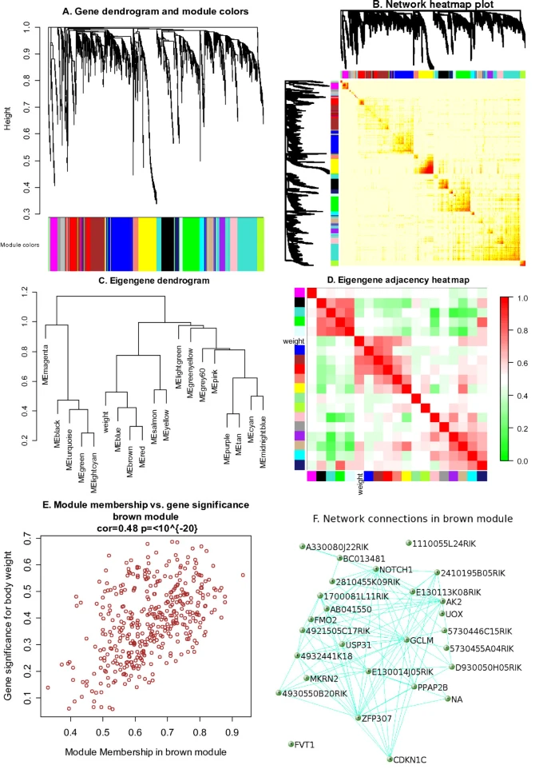

**Example WGCNA analysis of liver expression data in female mice**. A. Gene dendrogram obtained by average linkage hierarchical clustering. The color row underneath the dendrogram shows the module assignment determined by the Dynamic Tree Cut. B. Heatmap plot of topological overlap in the gene network. In the heatmap, each row and column corresponds to a gene, light color denotes low topological overlap, and progressively darker red denotes higher topological overlap. Darker squares along the diagonal correspond to modules. The gene dendrogram and module assignment are shown along the left and top. C. Hierarchical clustering of module eigengenes that summarize the modules found in the clustering analysis. Branches of the dendrogram (the meta-modules) group together eigengenes that are positively correlated. D. Heatmap plot of the adjacencies in the eigengene network including the trait weight. Each row and column in the heatmap corresponds to one module eigengene (labeled by color) or weight. In the heatmap, green color represents low adjacency (negative correlation), while red represents high adjacency (positive correlation). Squares of red color along the diagonal are the meta-modules. E. A scatterplot of gene significance for weight (GS, Equation 2) versus module membership (MM, Equation 6) in the brown module. GS and MM exhibit a very significant correlation, implying that hub genes of the brown module also tend to be highly correlated with weight. F. The network of the 30 most highly connected genes in the brown module. In this network we only display a connection of the corresponding topological overlap is above a threshold of 0.08.

[Full size image](https://bmcbioinformatics.biomedcentral.com/articles/10.1186/1471-2105-9-559/figures/4)

(7)

where *A*<sup>(*q*)</sup>denotes the *n*<sup>(*q*)</sup>× *n*<sup>(*q*)</sup>adjacency matrix corresponding to the sub-network formed by the genes of module *q*. Another useful concept is the *clustering coefficient* of gene *i*, which is a measure of 'cliquishness' [34]. Specifically,

(8)

In unweighted networks, *ClusterCoef*<sub>*i*</sub>equals 1 if and only if all neighbors of gene *i* are also linked to each other. For weighted networks, 0 ≤ *a*<sub>*ij*</sub>≤ 1 implies that 0 ≤ *ClusterCoef*<sub>*i*</sub>≤ 1 [5]. The mean clustering coefficient has been used to measure the extent of module structure present in a network [26, 34].

### Category 5: Functions for simulating microarray data with modular structure

Simple yet sufficiently realistic simulated data is often important for evaluation of novel data mining methods. The WGCNA package includes simulation functions simulateDatExpr, simulateMultiExpr, simulateDatExpr5Modules that result in expression data sets with a customizable modular (cluster) structure. The user can choose the modular structure by specifying a set of seed eigengenes, one for each module, around which each module is built. Module genes are simulated to exhibit progressively lower correlations with the seed which leads to genes with progressively lower intramodular connectivity. The user can specify module sizes and the number of background genes, i.e. genes outside of the modules. The seed eigengenes can be simulated to reflect dependence relationships between the modules (function simulateEigengeneNetwork).

### Category 6: Visualization functions

Module structure and network connections in the expression data can be visualized in several different ways. For example, the co-expression module structure can be visualized by heatmap plots of gene-gene connectivity that can be produced using the function TOMplot. Examples are presented in Figures 2C and 4B. An alternative is a multi-dimensional scaling plot; an example is presented in Figure 2B. Relationships among modules can be summarized by a hierarchical clustering dendrogram of their eigengenes, or by a heatmap plot of the corresponding eigengene network (function labeledHeatmap), illustrated in Figures 3C, D, and 4C, D. The package includes several additional functions designed to aid the user in visualizing input data and results. These functions rely on basic plotting functions provided in R and the packages sma [35] and fields [36].

### Category 7: Functions for interfacing with other software packages

To enhance the integration of WGCNA results with other network visualization packages and gene ontology analysis software, we have created several R functions and corresponding tutorials. For example, our R functions exportNetworkToVisANT and exportNetworkToCytoscape allow the user to export networks in a format suitable for VisANT [37] and Cytoscape [38], respectively.

Our online R tutorials also show how to interface WGCNA results with gene ontology packages available directly in R, e.g. GOSim [39]. Many gene ontology based functional enrichment analysis software programs such as David [40], AmiGO [41], Webgestalt [42] simply take lists of gene identifiers as input. Ingenuity Pathway Analysis allows the user to input gene expression data or gene identifiers.

### Mouse Data Application

As an example of the type of analysis one can perform with WGCNA, we describe a network analysis of liver expression data from female mice. The data and biological findings of this analysis have been described in [14]. Briefly, mRNA levels in female mouse livers were measured by microarrays with over 23,000 probe sets. In addition to the expression data, multiple physiological and metabolic traits were measured. For computational reasons, the original analysis presented in [14] was restricted to 3600 most connected genes, and for simplicity we will work with the same set of genes (although we note that the presented package is capable of handling all genes as well). While we do use the same data, the module detection methods are slightly different and the results are similar but not the same. The code used to perform this analysis is part of the tutorials posted on our webpage.

The network and the 18 identified modules are depicted in Figures 4A, B. To understand the physiologic significance of the modules, we correlated the 18 module eigengenes with physiological traits such as body weight, cholesterol level, insulin level. The full module-trait correlation table is presented in the accompanying tutorial.

In the following, we will only consider mouse body weight as sample trait. The module eigengenes of the following three modules were highly correlated with body weight: brown (409 genes, correlation with weight *r* = 0.59, correlation p-value *p* = 5 × 10<sup>-14</sup>), red (221 genes, *r* = 0.51, *p* = 3 × 10<sup>-10</sup>), and salmon (91 genes, *r* = 0.43, *p* = 2 × 10<sup>-7</sup>).

We used the online software David [40] to determine whether the three body weight related modules were significantly enriched with regard to known gene ontologies. The brown module is significantly enriched in categories "glycoprotein" (*p* = 2 × 10<sup>-24</sup>, Benjamini corrected) and "signal" (*p* = 1 × 10<sup>-22</sup>). The red module is enriched in "cell cycle" (*p* = 9 × 10<sup>-24</sup>) and "chromosome" (*p* = 5 × 10<sup>-20</sup>). The salmon module is most significantly enriched in the category "lipid synthesis" (*p* = 1 × 10<sup>-16</sup>). Overall, the high enrichment scores suggest that these modules are indeed biologically meaningful.

It is interesting to find centrally located intramodular hub genes in the body weight related modules since their expression profile represents that of the entire module [11]. To find intramodular hub genes, one can use the module membership measure *K*, Equation 6. Figure 4E shows a scatterplot between the body weight based gene significance measure *GS*<sub>*i*</sub>, Equation 2 and module membership in the brown module.

The high correlation between gene significance and module membership implies that hubgenes in the brown module also tend to be highly correlated with body weight. This suggests that both gene significance and module membership (intramodular connectivity) can be combined in a systems biologic screening method for finding body weight related genes [15]. Figure 4F shows a Visant plot among the most connected genes in the brown module. This brief description illustrates how WGCNA can lead to testable hypotheses that require validation in independent data sets. A tutorial underlying this example and Figure 4 can be found on our webpage.

### Tutorials

We provide a comprehensive set of online tutorials that guide the user through major steps of correlation network analysis. The tutorials provide R code the user can copy-and-paste into an R session, along with comments and explanations of both the input and output. The code is organized into short sections, each of which addresses a particular task. In particular, the tutorials cover the following topics: correlation network construction, step-by-step and automatic module detection, consensus module detection, eigengene network analysis, differential network analysis, interfacing with external software packages, and data simulation. The tutorials use both simulated and real gene expression data sets.

## Discussion

The WGCNA package complements other network related packages for R, such as the general network structures in Bioconductor [6], gene network enrichment analysis [43], functional analysis of gene co-expression networks [44], and others. While most of the existing packages focus only on unweighted networks, WGCNA implements methods for both weighted and unweighted correlation networks. WGCNA can be used as a data exploratory tool or as a gene screening (ranking) method. For example, WGCNA can be used to explore the module (cluster) structure in a network, to measure the relationships between genes and modules (module membership information), to explore the relationships among modules (eigengene networks), and to rank-order genes or modules (e.g. with regard to their relationship with a sample trait). WGCNA can be used to generate testable hypotheses for validation in independent data sets. For example, WGCNA may suggest that a module (e.g. a putative pathway) is associated with a disease outcome. Since correlation networks are based on correlations between quantitative variables, one can use a correlation test p-value [1] or a regression-based p-value for assessing the statistical significance between pairs of variables. For example, it is straightforward to attach a significance level to the fuzzy module membership measures . The relationship between standard microarray data mining techniques and gene co-expression network analysis is discussed in [11].

Users should be aware of the limitations of the methods implemented in the WGCNA package. First, WGCNA assumes that the microarray data have been properly pre-processed and normalized. To normalize the expression data, several R functions have been implemented in the Bioconductor packages [45]. Although all normalization methods are mathematically compatible with WGCNA, we recommend to use the biologically most meaningful normalization method with respect to the application under consideration. Second, similar to most other data mining methods, the results of WGCNA can be biased or invalid when dealing with technical artefacts, tissue contaminations, or poor experimental design. Third, although several co-expression module detection methods are implemented, the package does not provide means to determine which method is best. While the default hierarchical clustering methods have performed well in several real data applications, it would be desirable to compare these and other methods on multiple real benchmark data sets. Fourth, this package is limited to undirected networks. Methods for orienting edges and constructing directed networks have been presented in the literature, for example in [46–48].

## Conclusion

The WGCNA R package provides a comprehensive set of functions for performing weighted correlation network analysis. The WGCNA package can also be used to describe the correlation structure between gene expression profiles, image data, genetic marker data, proteomics data, and other high-dimensional data.

## Availability and requirements

Project name: WGCNA R package

Project home page: http://www.genetics.ucla.edu/labs/horvath/CoexpressionNetwork/Rpackages/WGCNA

Operating system(s): Platform independent

Programming language: R

Licence: GNU GPL 3

## Acknowledgements

We would like to thank Jun Dong, Tova Fuller, Dan Geschwind, Winden Kellen, Wen Lin, Jake Lusis, Mike Mason, Jeremy Miller, Paul Mischel, Stan Nelson, Mike Oldham, Angela Presson, Atila Van Nas, and Lin Wang for helpful discussions and suggestions. The work was supported in part by grants P50CA092131, 5P30CA016042-28, and NS050151-01.

## References

1. Fisher RA: On the 'probable error' of a coefficient of correlation deduced from a small sample. *Metron* 1915, 1: 1–32.

   Google Scholar
2. Zhou X, Kao MC, Wong W: Transitive Functional Annotation by Shortest-path Analysis of Gene Expression Data. *Proc Natl Acad Sci USA* 2002, 99(20):12783–12788.

   [Article](https://doi.org/10.1073%2Fpnas.192159399) [PubMed Central](http://www.ncbi.nlm.nih.gov/pmc/articles/PMC130537) [CAS](https://bmcbioinformatics.biomedcentral.com/articles/cas-redirect/1:CAS:528:DC%2BD38XnvFGhsLk%3D) [PubMed](http://www.ncbi.nlm.nih.gov/entrez/query.fcgi?cmd=Retrieve&db=PubMed&dopt=Abstract&list_uids=12196633) Google Scholar
3. Steffen M, Petti A, Aach J, D'haeseleer P, Church G: Automated modelling of signal transduction networks. *BMC Bioinformatics* 2002, 3: 34.

   [Article](https://doi.org/10.1186%2F1471-2105-3-34) [PubMed Central](http://www.ncbi.nlm.nih.gov/pmc/articles/PMC137599) [PubMed](http://www.ncbi.nlm.nih.gov/entrez/query.fcgi?cmd=Retrieve&db=PubMed&dopt=Abstract&list_uids=12413400) Google Scholar
4. Stuart JM, Segal E, Koller D, Kim SK: A Gene-Coexpression Network for Global Discovery of Conserved Genetic Modules. *Science* 2003, 302(5643):249–255.

   [Article](https://doi.org/10.1126%2Fscience.1087447) [CAS](https://bmcbioinformatics.biomedcentral.com/articles/cas-redirect/1:CAS:528:DC%2BD3sXnvFWgt7g%3D) [PubMed](http://www.ncbi.nlm.nih.gov/entrez/query.fcgi?cmd=Retrieve&db=PubMed&dopt=Abstract&list_uids=12934013) Google Scholar
5. Zhang B, Horvath S: A General Framework for Weighted Gene Co-expression Network Analysis. *Stat Appl Genet Mol Biol* 2005, 4: Article 17.

   Google Scholar
6. Carey VJ, Gentry J, Whalen E, Gentleman R: Network structures and algorithms in Bioconductor. *Bioinformatics* 2005, 21: 135–136.

   [Article](https://doi.org/10.1093%2Fbioinformatics%2Fbth458) [CAS](https://bmcbioinformatics.biomedcentral.com/articles/cas-redirect/1:CAS:528:DC%2BD2MXisVWjug%3D%3D) [PubMed](http://www.ncbi.nlm.nih.gov/entrez/query.fcgi?cmd=Retrieve&db=PubMed&dopt=Abstract&list_uids=15297301) Google Scholar
7. Schaefer J, Strimmer K: An empirical Bayes approach to inferring large-scale gene association networks. *Bioinformatics* 2005, 21(6):754–764.

   [Article](https://doi.org/10.1093%2Fbioinformatics%2Fbti062) [CAS](https://bmcbioinformatics.biomedcentral.com/articles/cas-redirect/1:CAS:528:DC%2BD2MXit1Kntr0%3D) Google Scholar
8. Chuang CL, Jen CH, Chen CM, Shieh GS: A pattern recognition approach to infer time-lagged genetic interactions. *Bioinformatics* 2008, 24(9):1183–1190.

   [Article](https://doi.org/10.1093%2Fbioinformatics%2Fbtn098) [CAS](https://bmcbioinformatics.biomedcentral.com/articles/cas-redirect/1:CAS:528:DC%2BD1cXlt1agsbY%3D) [PubMed](http://www.ncbi.nlm.nih.gov/entrez/query.fcgi?cmd=Retrieve&db=PubMed&dopt=Abstract&list_uids=18337258) Google Scholar
9. Cokus S, Rose S, Haynor D, Gronbech-Jensen N, Pellegrini M: Modelling the network of cell cycle transcription factors in the yeast Saccharomyces cerevisiae. *BMC Bioinformatics* 2006, 7: 381.

   [Article](https://doi.org/10.1186%2F1471-2105-7-381) [PubMed Central](http://www.ncbi.nlm.nih.gov/pmc/articles/PMC1570153) [PubMed](http://www.ncbi.nlm.nih.gov/entrez/query.fcgi?cmd=Retrieve&db=PubMed&dopt=Abstract&list_uids=16914048) Google Scholar
10. Horvath S, Zhang B, Carlson M, Lu K, Zhu S, Felciano R, Laurance M, Zhao W, Shu Q, Lee Y, Scheck A, Liau L, Wu H, Geschwind D, Febbo P, Kornblum H, Cloughesy T, Nelson S, Mischel P: Analysis of Oncogenic Signaling Networks in Glioblastoma Identifies ASPM as a Novel Molecular Target. *Proc Natl Acad Sci USA* 2006, 103(46):17402–17407.

    [Article](https://doi.org/10.1073%2Fpnas.0608396103) [PubMed Central](http://www.ncbi.nlm.nih.gov/pmc/articles/PMC1635024) [CAS](https://bmcbioinformatics.biomedcentral.com/articles/cas-redirect/1:CAS:528:DC%2BD28Xht1KqtL%2FM) [PubMed](http://www.ncbi.nlm.nih.gov/entrez/query.fcgi?cmd=Retrieve&db=PubMed&dopt=Abstract&list_uids=17090670) Google Scholar
11. Horvath S, Dong J: Geometric interpretation of Gene Co-expression Network Analysis. *PLoS Computational Biology* 2008.

    [Google Scholar](http://scholar.google.com/scholar_lookup?&title=Geometric%20interpretation%20of%20Gene%20Co-expression%20Network%20Analysis&publication_year=2008&author=Horvath%2CS&author=Dong%2CJ)
12. Langfelder P, Horvath S: Eigengene networks for studying the relationships between co-expression modules. *BMC Systems Biology* 2007, 1: 54.

    [Article](https://doi.org/10.1186%2F1752-0509-1-54) [PubMed Central](http://www.ncbi.nlm.nih.gov/pmc/articles/PMC2267703) [PubMed](http://www.ncbi.nlm.nih.gov/entrez/query.fcgi?cmd=Retrieve&db=PubMed&dopt=Abstract&list_uids=18031580) Google Scholar
13. Carlson MR, Zhang B, Fang Z, Horvath S, Mishel PS, Nelson SF: Gene Connectivity, Function, and Sequence Conservation: Predictions from Modular Yeast Co-expression Networks. *BMC Genomics* 2006., 7(40):

    Google Scholar
14. Ghazalpour A, Doss S, Zhang B, Plaisier C, Wang S, Schadt E, Thomas A, Drake T, Lusis A, Horvath S: Integrating Genetics and Network Analysis to Characterize Genes Related to Mouse Weight. *PloS Genetics* 2006, 2(8):e130.

    [Article](https://doi.org/10.1371%2Fjournal.pgen.0020130) [PubMed Central](http://www.ncbi.nlm.nih.gov/pmc/articles/PMC1550283) [PubMed](http://www.ncbi.nlm.nih.gov/entrez/query.fcgi?cmd=Retrieve&db=PubMed&dopt=Abstract&list_uids=16934000) Google Scholar
15. Fuller T, Ghazalpour A, Aten J, Drake T, Lusis A, Horvath S: Weighted Gene Co-expression Network Analysis Strategies Applied to Mouse Weight. *Mammalian Genome* 2007, 6(18):463–472.

    [Article](https://doi.org/10.1007%2Fs00335-007-9043-3) Google Scholar
16. Emilsson V, Thorleifsson G, Zhang B, Leonardson A, Zink F, Zhu J, Carlson S, Helgason A, Walters G, Gunnarsdottir S, Mouy M, Steinthorsdottir V, Eiriksdottir G, Bjornsdottir G, Reynisdottir I, Gudbjartsson D, Helgadottir A, Jonasdottir A, Jonasdottir A, Styrkarsdottir U, Gretarsdottir S, Magnusson K, Stefansson H, Fossdal R, Kristjansson K, Gislason H, Stefansson T, Leifsson B, Thorsteinsdottir U, Lamb J, Gulcher MJ, Reitman , Kong A, Schadt E, Stefansson K: Genetics of gene expression and its effect on disease. *Nature* 2008, 452(7186):423–8.

    [Article](https://doi.org/10.1038%2Fnature06758) [CAS](https://bmcbioinformatics.biomedcentral.com/articles/cas-redirect/1:CAS:528:DC%2BD1cXjslCnu74%3D) [PubMed](http://www.ncbi.nlm.nih.gov/entrez/query.fcgi?cmd=Retrieve&db=PubMed&dopt=Abstract&list_uids=18344981) Google Scholar
17. van Nas A, Guhathakurta D, Wang S, Yehya S, Horvath S, Zhang B, Ingram Drake L, Chaudhuri G, Schadt E, Drake T, Arnold A, Lusis A: Elucidating the Role of Gonadal Hormones in Sexually Dimorphic Gene Co-Expression Networks. *Endocrinology* 2008.

    Google Scholar
18. Oldham M, Horvath S, Geschwind D: Conservation and Evolution of Gene Co-expression Networks in Human and Chimpanzee Brains. *Proc Natl Acad Sci USA* 2006, 103(47):17973–17978.

    [Article](https://doi.org/10.1073%2Fpnas.0605938103) [PubMed Central](http://www.ncbi.nlm.nih.gov/pmc/articles/PMC1693857) [CAS](https://bmcbioinformatics.biomedcentral.com/articles/cas-redirect/1:CAS:528:DC%2BD28Xht1Kmsr7F) [PubMed](http://www.ncbi.nlm.nih.gov/entrez/query.fcgi?cmd=Retrieve&db=PubMed&dopt=Abstract&list_uids=17101986) Google Scholar
19. Miller JA, Oldham MC, Geschwind DH: A Systems Level Analysis of Transcriptional Changes in Alzheimer's Disease and Normal Aging. *J Neurosci* 2008, 28(6):1410–1420.

    [Article](https://doi.org/10.1523%2FJNEUROSCI.4098-07.2008) [PubMed Central](http://www.ncbi.nlm.nih.gov/pmc/articles/PMC2902235) [CAS](https://bmcbioinformatics.biomedcentral.com/articles/cas-redirect/1:CAS:528:DC%2BD1cXitVSqs78%3D) [PubMed](http://www.ncbi.nlm.nih.gov/entrez/query.fcgi?cmd=Retrieve&db=PubMed&dopt=Abstract&list_uids=18256261) Google Scholar
20. Oldham MC, Konopka G, Iwamoto K, Langfelder P, Kato T, Horvath S, Geschwind DH: Functional organization of the transcriptome in human brain. *Nature Neuroscience* 2008, 11(11):1271–1282.

    [Article](https://doi.org/10.1038%2Fnn.2207) [PubMed Central](http://www.ncbi.nlm.nih.gov/pmc/articles/PMC2756411) [CAS](https://bmcbioinformatics.biomedcentral.com/articles/cas-redirect/1:CAS:528:DC%2BD1cXht12ltrvE) [PubMed](http://www.ncbi.nlm.nih.gov/entrez/query.fcgi?cmd=Retrieve&db=PubMed&dopt=Abstract&list_uids=18849986) Google Scholar
21. Keller MP, Choi Y, Wang P, Belt Davis D, Rabaglia ME, Oler AT, Stapleton DS, Argmann C, Schueler KL, Edwards S, Steinberg HA, Chaibub Neto E, Kleinhanz R, Turner S, Hellerstein MK, Schadt EE, Yandell BS, Kendziorski C, Attie AD: A gene expression network model of type 2 diabetes links cell cycle regulation in islets with diabetes susceptibility. *Genome Res* 2008, 18(5):706–716.

    [Article](https://doi.org/10.1101%2Fgr.074914.107) [PubMed Central](http://www.ncbi.nlm.nih.gov/pmc/articles/PMC2336811) [CAS](https://bmcbioinformatics.biomedcentral.com/articles/cas-redirect/1:CAS:528:DC%2BD1cXlslChs7s%3D) [PubMed](http://www.ncbi.nlm.nih.gov/entrez/query.fcgi?cmd=Retrieve&db=PubMed&dopt=Abstract&list_uids=18347327) Google Scholar
22. Presson A, Sobel E, Papp J, Suarez C, Whistler T, Rajeevan M, Vernon S, Horvath S: Integrated weighted gene co-expression network analysis with an application to chronic fatigue syndrome. *BMC Systems Biology* 2008., 2(95):

    Google Scholar
23. Weston D, Gunter L, Rogers A, Wullschleger S: Connecting genes, coexpression modules, and molecular signatures to environmental stress phenotypes in plants. *BMC Systems Biology* 2008., 2:

    Google Scholar
24. Wilcox RR: *Introduction to Robust Estimation and Hypothesis Testing*. Academic Press; 1997.

    [Google Scholar](http://scholar.google.com/scholar_lookup?&title=Introduction%20to%20Robust%20Estimation%20and%20Hypothesis%20Testing&publication_year=1997&author=Wilcox%2CRR)
25. Yip A, Horvath S: Gene network interconnectedness and the generalized topological overlap measure. *BMC Bioinformatics* 2007, 8: 22.

    [Article](https://doi.org/10.1186%2F1471-2105-8-22) [PubMed Central](http://www.ncbi.nlm.nih.gov/pmc/articles/PMC1797055) [PubMed](http://www.ncbi.nlm.nih.gov/entrez/query.fcgi?cmd=Retrieve&db=PubMed&dopt=Abstract&list_uids=17250769) Google Scholar
26. Ravasz E, Somera A, Mongru D, Oltvai Z, Barabási A: Hierarchical Organization of Modularity in Metabolic Networks. *Science* 2002, 297(5586):1551–1555.

    [Article](https://doi.org/10.1126%2Fscience.1073374) [CAS](https://bmcbioinformatics.biomedcentral.com/articles/cas-redirect/1:CAS:528:DC%2BD38XmslSjtLs%3D) [PubMed](http://www.ncbi.nlm.nih.gov/entrez/query.fcgi?cmd=Retrieve&db=PubMed&dopt=Abstract&list_uids=12202830) Google Scholar
27. Li A, Horvath S: Network Neighborhood Analysis With the Multi-node Topological Overlap Measure. *Bioinformatics* 2007, 23(2):222–231.

    [Article](https://doi.org/10.1093%2Fbioinformatics%2Fbtl581) [PubMed](http://www.ncbi.nlm.nih.gov/entrez/query.fcgi?cmd=Retrieve&db=PubMed&dopt=Abstract&list_uids=17110366) Google Scholar
28. Kaufman L, Rousseeuw P: *Finding Groups in Data: An Introduction to Cluster Analysis*. New York: John Wiley & Sons, Inc; 1990.

    [Book](https://doi.org/10.1002%2F9780470316801) Google Scholar
29. Langfelder P, Zhang B, Horvath S: Defining clusters from a hierarchical cluster tree: the Dynamic Tree Cut package for R. *Bioinformatics* 2008, 24(5):719–720.

    [Article](https://doi.org/10.1093%2Fbioinformatics%2Fbtm563) [CAS](https://bmcbioinformatics.biomedcentral.com/articles/cas-redirect/1:CAS:528:DC%2BD1cXislKlt7k%3D) [PubMed](http://www.ncbi.nlm.nih.gov/entrez/query.fcgi?cmd=Retrieve&db=PubMed&dopt=Abstract&list_uids=18024473) Google Scholar
30. Dudoit S, Fridlyand J: A prediction-based resampling method for estimating the number of clusters in a dataset. *Genome Biol* 2002, 3(7):RESEARCH0036.

    [Article](https://doi.org/10.1186%2Fgb-2002-3-7-research0036) [PubMed Central](http://www.ncbi.nlm.nih.gov/pmc/articles/PMC126241) [PubMed](http://www.ncbi.nlm.nih.gov/entrez/query.fcgi?cmd=Retrieve&db=PubMed&dopt=Abstract&list_uids=12184810) Google Scholar
31. Hastie T, Tibshirani R, Sherlock G, Eisen M, Brown P, Botstein D: Imputing Missing Data for Gene Expression Arrays. *Technical report, Stanford Statistics Department* 1999.

    Google Scholar
32. Troyanskaya O, Cantor M, Sherlock G, Brown P, Hastie T, Tibshirani R, Botstein D, Altman RB: Missing value estimation methods for DNA microarrays. *Bioinformatics* 2001, 17(6):520–525.

    [Article](https://doi.org/10.1093%2Fbioinformatics%2F17.6.520) [CAS](https://bmcbioinformatics.biomedcentral.com/articles/cas-redirect/1:CAS:528:DC%2BD3MXltFOgsLY%3D) [PubMed](http://www.ncbi.nlm.nih.gov/entrez/query.fcgi?cmd=Retrieve&db=PubMed&dopt=Abstract&list_uids=11395428) Google Scholar
33. Dong J, Horvath S: Understanding network concepts in modules. *BMC Systems Biology* 2007, 1: 24.

    [Article](https://doi.org/10.1186%2F1752-0509-1-24) [PubMed Central](http://www.ncbi.nlm.nih.gov/pmc/articles/PMC3238286) [PubMed](http://www.ncbi.nlm.nih.gov/entrez/query.fcgi?cmd=Retrieve&db=PubMed&dopt=Abstract&list_uids=17547772) Google Scholar
34. Watts DJ, Strogatz SH: Collective dynamics of 'small-world' networks. *Nature* 1998, 393(6684):440–2.

    [Article](https://doi.org/10.1038%2F30918) [CAS](https://bmcbioinformatics.biomedcentral.com/articles/cas-redirect/1:CAS:528:DyaK1cXjs1Khsrk%3D) [PubMed](http://www.ncbi.nlm.nih.gov/entrez/query.fcgi?cmd=Retrieve&db=PubMed&dopt=Abstract&list_uids=9623998) Google Scholar
35. Dudoit S, Yang Y, Callow M, Speed T: Statistical methods for identifying differentially expressed genes in replicated cDNA microarray experiments. *Statistica Sinica* 2002.

    Google Scholar
36. (2006) FDT: fields: Tools for Spatial Data. *Tech. rep., National Center for Atmospheric Research, Boulder, CO* 2007. [http://www.image.ucar.edu/GSP/Software/Fields]

    [Google Scholar](http://scholar.google.com/scholar_lookup?&title=fields%3A%20Tools%20for%20Spatial%20Data&publication_year=2007)
37. Hu Z, Snitkin ES, DeLisi C: VisANT: an integrative framework for networks in systems biology. *Brief Bioinform* 2008, 9(4):317–325.

    [Article](https://doi.org/10.1093%2Fbib%2Fbbn020) [PubMed Central](http://www.ncbi.nlm.nih.gov/pmc/articles/PMC2743399) [CAS](https://bmcbioinformatics.biomedcentral.com/articles/cas-redirect/1:CAS:528:DC%2BD1cXpt1artrY%3D) [PubMed](http://www.ncbi.nlm.nih.gov/entrez/query.fcgi?cmd=Retrieve&db=PubMed&dopt=Abstract&list_uids=18463131) Google Scholar
38. Shannon P, Markiel A, Ozier O, Baliga NS, Wang JT, Ramage D, Amin N, Schwikowski B, Ideker T: Cytoscape: A Software Environment for Integrated Models of Biomolecular Interaction Networks. *Genome Research* 2003, 13(11):2498–2504.

    [Article](https://doi.org/10.1101%2Fgr.1239303) [PubMed Central](http://www.ncbi.nlm.nih.gov/pmc/articles/PMC403769) [CAS](https://bmcbioinformatics.biomedcentral.com/articles/cas-redirect/1:CAS:528:DC%2BD3sXovFWrtr4%3D) [PubMed](http://www.ncbi.nlm.nih.gov/entrez/query.fcgi?cmd=Retrieve&db=PubMed&dopt=Abstract&list_uids=14597658) Google Scholar
39. Frohlich H, Speer N, Poustka A, BeiSZbarth T: GOSim – an R-package for computation of information theoretic GO similarities between terms and gene products. *BMC Bioinformatics* 2007., 8:

    Google Scholar
40. Dennis G, Sherman B, Hosack D, Yang J, Gao W, Lane H, Lempicki R: DAVID: Database for Annotation, Visualization, and Integrated Discovery. *Genome Biol* 2003, 4(5):P3.

    [Article](https://doi.org/10.1186%2Fgb-2003-4-5-p3) [PubMed](http://www.ncbi.nlm.nih.gov/entrez/query.fcgi?cmd=Retrieve&db=PubMed&dopt=Abstract&list_uids=12734009) Google Scholar
41. Ashburner M, Ball CA, Blake JA, Botstein D, Butler H, Cherry JM, Davis AP, Dolinski K, Dwight SS, Eppig JT, Harris MA, Hill DP, Issel-Tarver L, Kasarskis A, Lewis S, Matese JC, Richardson JE, Ringwald M, Rubin GM, Sherlock G: Gene Ontology: tool for the unification of biology. *Nat Genet* 2000, 25: 25–29.

    [Article](https://doi.org/10.1038%2F75556) [PubMed Central](http://www.ncbi.nlm.nih.gov/pmc/articles/PMC3037419) [CAS](https://bmcbioinformatics.biomedcentral.com/articles/cas-redirect/1:CAS:528:DC%2BD3cXjtFSlsbc%3D) [PubMed](http://www.ncbi.nlm.nih.gov/entrez/query.fcgi?cmd=Retrieve&db=PubMed&dopt=Abstract&list_uids=10802651) Google Scholar
42. Zhang B, Kirov S, Snoddy J: WebGestalt: an integrated system for exploring gene sets in various biological contexts. *Nucleic Acids Res* 2005, 33(Web Server issue):W741-W748.

    [Article](https://doi.org/10.1093%2Fnar%2Fgki475) [PubMed Central](http://www.ncbi.nlm.nih.gov/pmc/articles/PMC1160236) [CAS](https://bmcbioinformatics.biomedcentral.com/articles/cas-redirect/1:CAS:528:DC%2BD2MXlslyqtLY%3D) [PubMed](http://www.ncbi.nlm.nih.gov/entrez/query.fcgi?cmd=Retrieve&db=PubMed&dopt=Abstract&list_uids=15980575) Google Scholar
43. Liu M, Liberzon A, Kong SW, Lai WR, Park PJ, Kohane IS, Kasif S: Network-Based Analysis of Affected Biological Processes in Type 2 Diabetes Models. *PLoS Genet* 2007, 3(6):e96.

    [Article](https://doi.org/10.1371%2Fjournal.pgen.0030096) [PubMed Central](http://www.ncbi.nlm.nih.gov/pmc/articles/PMC1904360) [PubMed](http://www.ncbi.nlm.nih.gov/entrez/query.fcgi?cmd=Retrieve&db=PubMed&dopt=Abstract&list_uids=17571924) Google Scholar
44. Henegar C, Clement K, Zucker JD: Unsupervised Multiple-Instance Learning for Functional Profiling of Genomic Data. In *Machine Learning: ECML 2006*. Springer Berlin/Heidelberg; 2006:186–197.

    [Chapter](https://doi.org/10.1007%2F11871842_21) Google Scholar
45. Gentleman R, Huber W, Carey V, Irizarry R, Dudoit S: Bioinformatics and Computational Biology Solutions Using R and Bioconductor. In *Book*. Springer-Verlag New York; 2005.

    Google Scholar
46. Opgen-Rhein R, Strimmer K: From correlation to causation networks: a simple approximate learning algorithm and its application to high-dimensional plant gene expression data. *BMC Systems Biology* 2007., 1:

    Google Scholar
47. Aten J, Fuller T, Lusis A, Horvath S: Using genetic markers to orient the edges in quantitative trait networks: The NEO software. *BMC Systems Biology* 2008., 2:

    Google Scholar
48. Chaibub Neto E, Ferrara CT, Attie AD, Yandell BS: Inferring Causal Phenotype Networks From Segregating Populations. *Genetics* 2008, 179(2):1089–1100.

    [Article](https://doi.org/10.1534%2Fgenetics.107.085167) [PubMed Central](http://www.ncbi.nlm.nih.gov/pmc/articles/PMC2429862) [PubMed](http://www.ncbi.nlm.nih.gov/entrez/query.fcgi?cmd=Retrieve&db=PubMed&dopt=Abstract&list_uids=18505877) Google Scholar

[Download references](https://citation-needed.springer.com/v2/references/10.1186/1471-2105-9-559?format=refman&flavour=references)

## Author information

### Authors and Affiliations

1. Department of Human Genetics, University of California, Los Angeles, CA, 90095, USA

   Peter Langfelder
2. Department of Human Genetics and Department of Biostatistics, University of California, Los Angeles, CA, 90095, USA

   Steve Horvath

### Corresponding author

Correspondence to Steve Horvath.

## Additional information

### Authors' contributions

Both authors jointly developed the methods and wrote the article. PL packaged the functions into an R package. Both authors read and approved the final manuscript.

## Authors’ original submitted files for images

Below are the links to the authors’ original submitted files for images.

### [Authors’ original file for figure 1](https://static-content.springer.com/esm/art%3A10.1186%2F1471-2105-9-559/MediaObjects/12859_2008_2544_MOESM1_ESM.pdf)

### [Authors’ original file for figure 2](https://static-content.springer.com/esm/art%3A10.1186%2F1471-2105-9-559/MediaObjects/12859_2008_2544_MOESM2_ESM.pdf)

### [Authors’ original file for figure 3](https://static-content.springer.com/esm/art%3A10.1186%2F1471-2105-9-559/MediaObjects/12859_2008_2544_MOESM3_ESM.pdf)

### [Authors’ original file for figure 4](https://static-content.springer.com/esm/art%3A10.1186%2F1471-2105-9-559/MediaObjects/12859_2008_2544_MOESM4_ESM.pdf)

## Rights and permissions

This article is published under license to BioMed Central Ltd. This is an Open Access article distributed under the terms of the Creative Commons Attribution License (http://creativecommons.org/licenses/by/2.0), which permits unrestricted use, distribution, and reproduction in any medium, provided the original work is properly cited.

Reprints and permissions

## About this article

### Cite this article

Langfelder, P., Horvath, S. WGCNA: an R package for weighted correlation network analysis. *BMC Bioinformatics* **9**, 559 (2008). https://doi.org/10.1186/1471-2105-9-559

[Download citation](https://citation-needed.springer.com/v2/references/10.1186/1471-2105-9-559?format=refman&flavour=citation)

- Received: 24 July 2008
- Accepted: 29 December 2008
- Published: 29 December 2008
- DOI: https://doi.org/10.1186/1471-2105-9-559

### Share this article

Anyone you share the following link with will be able to read this content:

Provided by the Springer Nature SharedIt content-sharing initiative

### Keywords

- [Correlation Network](https://bmcbioinformatics.biomedcentral.com/search?query=Correlation%20Network&facet-discipline=%20Life%20Sciences%20)
- [Module Membership](https://bmcbioinformatics.biomedcentral.com/search?query=Module%20Membership&facet-discipline=%20Life%20Sciences%20)
- [Module Eigengene](https://bmcbioinformatics.biomedcentral.com/search?query=Module%20Eigengene&facet-discipline=%20Life%20Sciences%20)
- [Brown Module](https://bmcbioinformatics.biomedcentral.com/search?query=Brown%20Module&facet-discipline=%20Life%20Sciences%20)
- [Hierarchical Cluster Dendrogram](https://bmcbioinformatics.biomedcentral.com/search?query=Hierarchical%20Cluster%20Dendrogram&facet-discipline=%20Life%20Sciences%20)

[Download PDF](https://bmcbioinformatics.biomedcentral.com/counter/pdf/10.1186/1471-2105-9-559.pdf)

#### BMC Bioinformatics

ISSN: 1471-2105

#### Contact us

- General enquiries: journalsubmissions@springernature.com

[figure not shown]